# Introduction - Peiran Long

In this tutorial I will walk you through a brief introduction on what data science is and how Python is used to perform data analysis, and more specifically I will be showing you how to use some of the basic methods and packages to analyze dataset.

# 1. Preparation

## 1.1 Use the right libraries

One of the reasons of why Python has been gainning its popularity is that it has a huge set of libraries ready to be used. Unlike Java or C/C++, with the help of these libraries, Python is a very "efficient" language, and by "efficient" I do not mean that Python runs faster, but that it is easy to use and thus facilitates the work. The libraries that I am going to use in this tutorial are as listed below with a short description.

NumPy: A powerful and almost necessary package for scientific studies and data analysis, it provides a set of methods that allow users to manipulate N-dimensional arrary objects.

Pandas: Pandas supports a set of data structures including tables and series, and it works closely with NumPy. Pandas is heavily used to store and process formatted data (e.g., csv files, json files html tables and etc.)

Matplotlib: Matplotlib offers a plotting function that can is mainly used for data visualization.

```python
import numpy as np
import pandas as pd
import matplotlib.pyplot as plt
%matplotlib inline
```

## 1.2 Data collection

There are two ways of getting data. You can either scrape data from websites and other data sources, or you can download datasets from online platforms like Kaggle. Both of these methods have their advantages and disadvantages, and how to choose the proper way of collecting data is crucial to data science.

Scraping raw data is a more timely-manner method compared to downloading datasets, because online datasets are often collected a long time ago and may not be able to correctly represent the problem in time. The update of online datasets is utterly up to the uploader and sometimes the uploader would stop updating for various reasons. Although online datasets could be collected long before, there are some exceptions. If the source from which the online dataset is collected has stopped updating or has a long cycle of updating, then the dataset can be seen as up to date. For example, a dataset of World War II is always up to date, becuase the war is already finished and the event itself will never generate new data.

Using ready-to-go datasets can save a lot of time because data scraping is a very time-consuming process. Scraping raw data involves locating the source of data, collecting the data and tidying the data. The time spent on each of these three steps can vary greatly and is largely determined by the format and the tidiness of the raw data. On the other hands, the online datasets are easy to use because they are already tidyed by the data miners and are put into easily accessible formats (e.g., csv files and character delimited text files).

In this tutorial, I will be using a dataset available on Kaggle (https://www.kaggle.com/datasnaek/youtube-new)

### 1.2.1 Import the data

The following code showcases the easiness of using Python and online datasets. Without additional steps, the ready-to-go dataset named 'USvideos.csv' is imported in to a Pandas DataFrame.

```python
data = pd.read_csv('youtube-new/USvideos.csv')
data.head()
```

|  | video_id | trending_date | title | channel_title | category_id | publish_time | tags | views | likes | dislikes | comment_count | thumbnail_link | comments_disabled | ratings_disabled | video_error_or_removed | description |
| --- | --- | --- | --- | --- | --- | --- | --- | --- | --- | --- | --- | --- | --- | --- | --- | --- |
| 0 | 2kyS6SvSYSE | 17.14.11 | WE WANT TO TALK ABOUT OUR MARRIAGE | CaseyNeistat | 22 | 2017-11-13T17:13:01.000Z | SHANtell martin | 748374 | 57527 | 2966 | 15954 | https://i.ytimg.com/vi/2kyS6SvSYSE/default.jpg | False | False | False | SHANTELL'S CHANNEL - https://www.youtube.com/s... |
| 1 | 1ZAPwfrtAFY | 17.14.11 | The Trump Presidency: Last Week Tonight with J... | LastWeekTonight | 24 | 2017-11-13T07:30:00.000Z | last week tonight trump presidency\|"last week ... | 2418783 | 97185 | 6146 | 12703 | https://i.ytimg.com/vi/1ZAPwfrtAFY/default.jpg | False | False | False | One year after the presidential election, John... |
| 2 | 5qpjK5DgCt4 | 17.14.11 | Racist Superman \| Rudy Mancuso, King Bach & Le... | Rudy Mancuso | 23 | 2017-11-12T19:05:24.000Z | racist superman\|"rudy"\|"mancuso"\|"king"\|"bach"... | 3191434 | 146033 | 5339 | 8181 | https://i.ytimg.com/vi/5qpjK5DgCt4/default.jpg | False | False | False | WATCH MY PREVIOUS VIDEO ▶ \n\nSUBSCRIBE ► http... |
| 3 | puqaWrEC7tY | 17.14.11 | Nickelback Lyrics: Real or Fake? | Good Mythical Morning | 24 | 2017-11-13T11:00:04.000Z | rhett and link\|"gmm"\|"good mythical morning"\|"... | 343168 | 10172 | 666 | 2146 | https://i.ytimg.com/vi/puqaWrEC7tY/default.jpg | False | False | False | Today we find out if Link is a Nickelback amat... |
| 4 | d380meD0W0M | 17.14.11 | I Dare You: GOING BALD!? | nigahiga | 24 | 2017-11-12T18:01:41.000Z | ryan\|"higa"\|"higatv"\|"nigahiga"\|"i dare you"\|"... | 2095731 | 132235 | 1989 | 17518 | https://i.ytimg.com/vi/d380meD0W0M/default.jpg | False | False | False | I know it's been a while since we did this sho... |

# 2. Data Processing

Even though this dataset is downloaded from an online platforms, there is still some tidying work we can do. The main purpose of tidying is to make the later analysis easier, so it is fairly important to know what kinds of analysis you are going to perform in order to properly organize the data.

## 2.1 Formatting and tidying data

### 2.1.1 Datetime

Now, if we want to plot the total views each day vs. date, we can use Matplotlib function:

```
                                        plt.plot(dates,views)
```

But unfortunately this won't work, because all the values in the date column are strings, and since strings cannot be directly compared, the plotting function won't be able to establish the x axis based on the **data.trending_date**. Here, the solution is to use library **datetime**. Using **datetime.strptime()**, we can convert the non-comparable strings to comparable **datetime** objects.

```python
import datetime as dt

data.trending_date = list(map(lambda x: dt.datetime.strptime(x, '%y.%d.%m'),data.trending_date))
data.publish_time = list(map(lambda x: dt.datetime.strptime(x, '%Y-%m-%dT%H:%M:%S.000Z'),data.publish_time))

data.head()
```

|  | video_id | trending_date | title | channel_title | category_id | publish_time | tags | views | likes | dislikes | comment_count | thumbnail_link | comments_disabled | ratings_disabled | video_error_or_removed | description |
| --- | --- | --- | --- | --- | --- | --- | --- | --- | --- | --- | --- | --- | --- | --- | --- | --- |
| 0 | 2kyS6SvSYSE | 2017-11-14 | WE WANT TO TALK ABOUT OUR MARRIAGE | CaseyNeistat | 22 | 2017-11-13 17:13:01 | SHANtell martin | 748374 | 57527 | 2966 | 15954 | https://i.ytimg.com/vi/2kyS6SvSYSE/default.jpg | False | False | False | SHANTELL'S CHANNEL - https://www.youtube.com/s... |
| 1 | 1ZAPwfrtAFY | 2017-11-14 | The Trump Presidency: Last Week Tonight with J... | LastWeekTonight | 24 | 2017-11-13 07:30:00 | last week tonight trump presidency\|"last week ... | 2418783 | 97185 | 6146 | 12703 | https://i.ytimg.com/vi/1ZAPwfrtAFY/default.jpg | False | False | False | One year after the presidential election, John... |
| 2 | 5qpjK5DgCt4 | 2017-11-14 | Racist Superman \| Rudy Mancuso, King Bach & Le... | Rudy Mancuso | 23 | 2017-11-12 19:05:24 | racist superman\|"rudy"\|"mancuso"\|"king"\|"bach"... | 3191434 | 146033 | 5339 | 8181 | https://i.ytimg.com/vi/5qpjK5DgCt4/default.jpg | False | False | False | WATCH MY PREVIOUS VIDEO ▶ \n\nSUBSCRIBE ► http... |
| 3 | puqaWrEC7tY | 2017-11-14 | Nickelback Lyrics: Real or Fake? | Good Mythical Morning | 24 | 2017-11-13 11:00:04 | rhett and link\|"gmm"\|"good mythical morning"\|"... | 343168 | 10172 | 666 | 2146 | https://i.ytimg.com/vi/puqaWrEC7tY/default.jpg | False | False | False | Today we find out if Link is a Nickelback amat... |
| 4 | d380meD0W0M | 2017-11-14 | I Dare You: GOING BALD!? | nigahiga | 24 | 2017-11-12 18:01:41 | ryan\|"higa"\|"higatv"\|"nigahiga"\|"i dare you"\|"... | 2095731 | 132235 | 1989 | 17518 | https://i.ytimg.com/vi/d380meD0W0M/default.jpg | False | False | False | I know it's been a while since we did this sho... |

### 2.1.2 Tags

Similar to what what we did with the dates, the next step we are going to do is to convert the values in the **tags** column to a list of strings from a '|' delimited string. This conversion will help us retrieve the tags eaiser for the laster analysis.

```python
str_tags = data.tags
list_tags = []
for x in str_tags:
    list_tags.append([y.strip('"').strip() for y in x.split('|')])

data.tags = list_tags

data.head()
```

|  | video_id | trending_date | title | channel_title | category_id | publish_time | tags | views | likes | dislikes | comment_count | thumbnail_link | comments_disabled | ratings_disabled | video_error_or_removed | description |
| --- | --- | --- | --- | --- | --- | --- | --- | --- | --- | --- | --- | --- | --- | --- | --- | --- |
| 0 | 2kyS6SvSYSE | 2017-11-14 | WE WANT TO TALK ABOUT OUR MARRIAGE | CaseyNeistat | 22 | 2017-11-13 17:13:01 | [SHANtell martin] | 748374 | 57527 | 2966 | 15954 | https://i.ytimg.com/vi/2kyS6SvSYSE/default.jpg | False | False | False | SHANTELL'S CHANNEL - https://www.youtube.com/s... |
| 1 | 1ZAPwfrtAFY | 2017-11-14 | The Trump Presidency: Last Week Tonight with J... | LastWeekTonight | 24 | 2017-11-13 07:30:00 | [last week tonight trump presidency, last week... | 2418783 | 97185 | 6146 | 12703 | https://i.ytimg.com/vi/1ZAPwfrtAFY/default.jpg | False | False | False | One year after the presidential election, John... |
| 2 | 5qpjK5DgCt4 | 2017-11-14 | Racist Superman \| Rudy Mancuso, King Bach & Le... | Rudy Mancuso | 23 | 2017-11-12 19:05:24 | [racist superman, rudy, mancuso, king, bach, r... | 3191434 | 146033 | 5339 | 8181 | https://i.ytimg.com/vi/5qpjK5DgCt4/default.jpg | False | False | False | WATCH MY PREVIOUS VIDEO ▶ \n\nSUBSCRIBE ► http... |
| 3 | puqaWrEC7tY | 2017-11-14 | Nickelback Lyrics: Real or Fake? | Good Mythical Morning | 24 | 2017-11-13 11:00:04 | [rhett and link, gmm, good mythical morning, r... | 343168 | 10172 | 666 | 2146 | https://i.ytimg.com/vi/puqaWrEC7tY/default.jpg | False | False | False | Today we find out if Link is a Nickelback amat... |
| 4 | d380meD0W0M | 2017-11-14 | I Dare You: GOING BALD!? | nigahiga | 24 | 2017-11-12 18:01:41 | [ryan, higa, higatv, nigahiga, i dare you, idy... | 2095731 | 132235 | 1989 | 17518 | https://i.ytimg.com/vi/d380meD0W0M/default.jpg | False | False | False | I know it's been a while since we did this sho... |

# 3. Exploratory Analysis & Data Visualization

## 3.1 Total views vs. date

### 3.1.1 A simple plot

Now, we have a table with everything formatted to our needs, the next step is to find out the total views in each day.

First, we list out all the different dates in which the trending videos were recorded. This is done with Pandas **unique()** function which returns a set of all the values in a column.

Then, all the views within one day were summed together with the aggregate function **sum()**, and by going through each element in **dates**, the total views of all the trending vidoes in each day were put into a list called **views**

Last, we convrt the unit of views into million.

```python
dates = data.trending_date.unique()
views = []
for date in dates:
    views.append(data[data.trending_date==date].views.sum()/1000000)
df1 = pd.DataFrame({'date':dates,'views_million':views})
df1.head()
```

|  | date | views_million |
| --- | --- | --- |
| 0 | 2017-11-14 | 185.435246 |
| 1 | 2017-11-15 | 212.445216 |
| 2 | 2017-11-16 | 227.365391 |
| 3 | 2017-11-17 | 193.541711 |
| 4 | 2017-11-18 | 196.846875 |

**Then here comes our first plot!**

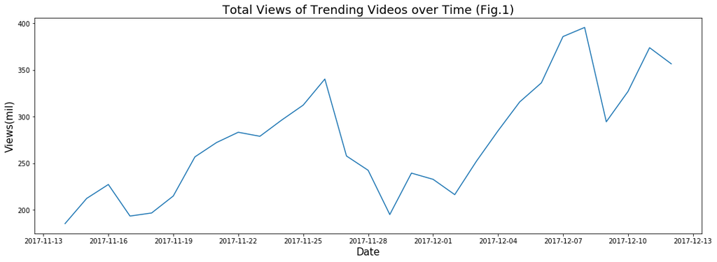

```python
fig,ax = plt.subplots()
ax.plot(df1.date,df1.views_million)
plt.title('Total Views of Trending Videos over Time (Fig.1)',fontsize=18)
ax.set_xlabel('Date',fontsize=15)
ax.set_ylabel('Views(mil)',fontsize=15)
fig.set_size_inches(18, 6)
```

### 3.1.2 What do we find

Looking at fig.1, we can easily find that there is a wave-like pattern in the views over time. Now let's assume that this pattern is not random but instead it has a reason. To find out the reason to this pattern we start with making guesses, and let's guess this pattern is related to what day it is in a week. We need to verify if our guess is correct, so let's highlight weekends and see if it matches the pattern.

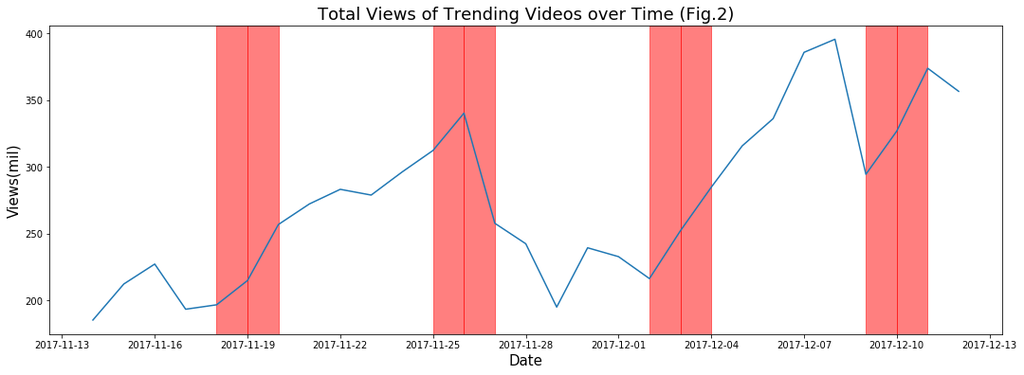

```python
import matplotlib.dates as mdates

fig,ax = plt.subplots()
ax.plot(df1.date,df1.views_million)
plt.title('Total Views of Trending Videos over Time (Fig.2)',fontsize=18)
ax.set_xlabel('Date',fontsize=15)
ax.set_ylabel('Views(mil)',fontsize=15)
fig.set_size_inches(18, 6)

df1['weekday'] = list(map(lambda x: x.weekday(),df1.date))
for i in range(len(df1)):
    day = df1.iloc[i].weekday
    if day >= 5:
        ax.axvspan(*mdates.drange(df1.iloc[i].date,df1.iloc[i+2].date,dt.timedelta(days=1)),color='red',alpha=0.5)
```

In fig.2, we can see that except for the weekend starting on 2017-11-25, all other weekends overlap with the rise in views, meaning that there is a high possibility that views are related to the days in a week.

## 3.2 Tag distribution

Now let's draw another plot that needs a bit more digging into the data. Let's find out the relationship between different tags and views, likes, dislikes and number of comments. This relationship will give us some insights into what the trending topics are and whether people are positive or negative about it.

### 3.2.1 Organize the data

As mentioned above, in practices, planning ahead can save a lot of time. Since we have already put the tags in the original dataset into lists, we can now easily access each tag of the video as find out other relative information.

```python
tags_count = {}
tags = data.tags
for tag in tags:
    for x in tag:
        if x in tags_count:
            tags_count[x] += 1
        else:
            tags_count[x] = 1
df2 = pd.DataFrame({'tag':list(tags_count.keys())})
df2['count'] = list(tags_count.values())

df2.head()
```

|  | tag | count |
| --- | --- | --- |
| 0 | SHANtell martin | 7 |
| 1 | last week tonight trump presidency | 7 |
| 2 | last week tonight donald trump | 7 |
| 3 | john oliver trump | 7 |
| 4 | donald trump | 24 |

```python
tags_views = {}
tags_likes = {}
tags_dislikes = {}
tags_comment = {}
for i in range(len(data)):
    for tag in data.iloc[i].tags:
        if tag in tags_views:
            tags_views[tag] += data.iloc[i].views
            tags_likes[tag] += data.iloc[i].likes
            tags_dislikes[tag] += data.iloc[i].dislikes
            tags_comment[tag] += data.iloc[i].comment_count
        else:
            tags_views[tag] = data.iloc[i].views
            tags_likes[tag] = data.iloc[i].likes
            tags_dislikes[tag] = data.iloc[i].dislikes
            tags_comment[tag] = data.iloc[i].comment_count

df3 = pd.DataFrame({'tag':list(tags_views.keys())})
df3['views'] = list(tags_views.values())
df3['likes'] = list(tags_likes.values())
df3['dislikes'] = list(tags_dislikes.values())
df3['comment'] = list(tags_comment.values())

df3 = df3.join(df2['count'],how='left')

df3.head()
```

|  | tag | views | likes | dislikes | comment | count |
| --- | --- | --- | --- | --- | --- | --- |
| 0 | SHANtell martin | 15220962 | 615779 | 49012 | 149396 | 7 |
| 1 | last week tonight trump presidency | 35193405 | 954559 | 71164 | 127113 | 7 |
| 2 | last week tonight donald trump | 35193405 | 954559 | 71164 | 127113 | 7 |
| 3 | john oliver trump | 35193405 | 954559 | 71164 | 127113 | 7 |
| 4 | donald trump | 37041288 | 1012747 | 75633 | 134664 | 24 |

### 3.2.2 Analyze the data

Now let's reorder the table based on each of the attributes.

```python
from IPython.display import display, HTML

df_tags = df3.sort_values(by='count',ascending=False)
df_tags.index = np.arange(0,len(df_tags))

df_views = df3.sort_values(by='views',ascending=False)
df_views['views_per_tag'] = (df3.views/df3['count']).astype(int)
df_views.index = np.arange(0,len(df_views))

df_likes = df3.sort_values(by='likes',ascending=False)
df_likes['likes_per_tag'] = (df3.likes/df3['count']).astype(int)
df_likes.index = np.arange(0,len(df_likes))

df_dislikes = df3.sort_values(by='dislikes',ascending=False)
df_dislikes['dislikes_per_tag'] = (df3.dislikes/df3['count']).astype(int)
df_dislikes.index = np.arange(0,len(df_dislikes))

df_comment = df3.sort_values(by='comment',ascending=False)
df_comment['comment_per_tag'] = (df3.comment/df3['count']).astype(int)
df_comment.index = np.arange(0,len(df_comment))

display(df_tags.head())
display(df_views.head())
display(df_likes.head())
display(df_dislikes.head())
display(df_comment.head())
```

|  | tag | views | likes | dislikes | comment | count |
| --- | --- | --- | --- | --- | --- | --- |
| 0 | funny | 739219132 | 23250248 | 736031 | 2507551 | 575 |
| 1 | comedy | 424974929 | 18558262 | 555706 | 2102640 | 443 |
| 2 | 2017 | 188485477 | 6379956 | 244067 | 924518 | 262 |
| 3 | music | 259096788 | 7621017 | 250613 | 565765 | 212 |
| 4 | christmas | 136557953 | 6285784 | 228869 | 944854 | 205 |

|  | tag | views | likes | dislikes | comment | count | views_per_tag |
| --- | --- | --- | --- | --- | --- | --- | --- |
| 0 | Pop | 1085069253 | 45010000 | 1294295 | 2683038 | 193 | 5622120 |
| 1 | funny | 739219132 | 23250248 | 736031 | 2507551 | 575 | 1285598 |
| 2 | Lovato | 709311244 | 26118715 | 927378 | 1538724 | 26 | 27281201 |
| 3 | Demi | 709311244 | 26118715 | 927378 | 1538724 | 26 | 27281201 |
| 4 | marvel | 684157305 | 22314773 | 424781 | 2979942 | 45 | 15203495 |

|  | tag | views | likes | dislikes | comment | count | likes_per_tag |
| --- | --- | --- | --- | --- | --- | --- | --- |
| 0 | Pop | 1085069253 | 45010000 | 1294295 | 2683038 | 193 | 233212 |
| 1 | Demi | 709311244 | 26118715 | 927378 | 1538724 | 26 | 1004565 |
| 2 | Lovato | 709311244 | 26118715 | 927378 | 1538724 | 26 | 1004565 |
| 3 | 방탄소년단 | 271948427 | 26059279 | 350266 | 4207435 | 28 | 930688 |
| 4 | BTS | 256345798 | 25312096 | 338227 | 4146421 | 27 | 937485 |

|  | tag | views | likes | dislikes | comment | count | dislikes_per_tag |
| --- | --- | --- | --- | --- | --- | --- | --- |
| 0 | Stephen Colbert | 617642971 | 17280055 | 6981119 | 4558889 | 71 | 98325 |
| 1 | Lele Pons | 559351544 | 16278084 | 6973914 | 4426947 | 20 | 348695 |
| 2 | Daddy Yankee | 529681073 | 15045728 | 6936669 | 4377838 | 14 | 495476 |
| 3 | youtube rewind 2017 | 509959581 | 14219299 | 6909482 | 4358929 | 19 | 363656 |
| 4 | I’m the One | 519199161 | 14154311 | 6894942 | 4324769 | 16 | 430933 |

|  | tag | views | likes | dislikes | comment | count | comment_per_tag |
| --- | --- | --- | --- | --- | --- | --- | --- |
| 0 | Stephen Colbert | 617642971 | 17280055 | 6981119 | 4558889 | 71 | 64209 |
| 1 | Lele Pons | 559351544 | 16278084 | 6973914 | 4426947 | 20 | 221347 |
| 2 | Daddy Yankee | 529681073 | 15045728 | 6936669 | 4377838 | 14 | 312702 |
| 3 | youtube rewind 2017 | 509959581 | 14219299 | 6909482 | 4358929 | 19 | 229417 |
| 4 | I’m the One | 519199161 | 14154311 | 6894942 | 4324769 | 16 | 270298 |

After organizing and reordering the data, we can easily see some facts about the trending vidoes.

*The top five most used tags are:*

```
                            funny, comedy, 2017, music and christmas
```

*The top five most watched tags are:*

```
                              Pop, funny, Lovato, Demi and Marvel
```

*The top five most liked tags are:*

```
                              Pop, Demi, Lovato, 방탄소년단 and BTS
```

*The top five most disliked tags are:*

```
            Stephen Colbert, Lele Pons, Daddy Yankee, youtube rewind 2017 and I’m the One
```

*The top five most commented tags are (exactly the same as the top 5 most disliked tags):*

```
            Stephen Colbert, Lele Pons, Daddy Yankee, youtube rewind 2017 and I’m the One
```

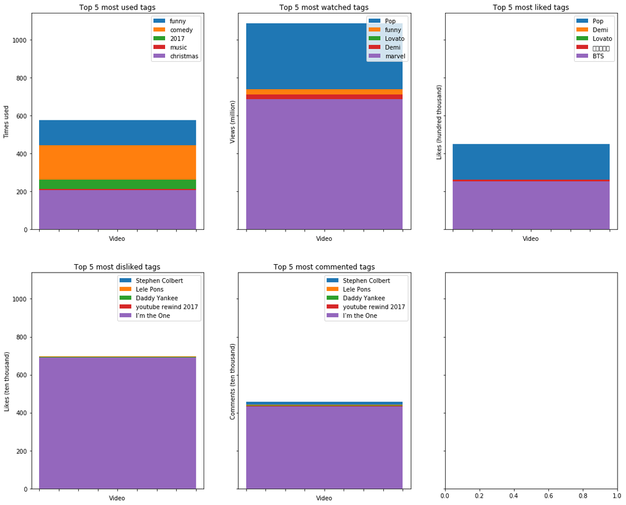

```python
fig,ax = plt.subplots(2,3,sharey=True)
ax[0,0].bar([0],[df_tags['count'][0]],label=df_tags.tag[0])
ax[0,0].bar([0],[df_tags['count'][1]],label=df_tags.tag[1])
ax[0,0].bar([0],[df_tags['count'][2]],label=df_tags.tag[2])
ax[0,0].bar([0],[df_tags['count'][3]],label=df_tags.tag[3])
ax[0,0].bar([0],[df_tags['count'][4]],label=df_tags.tag[4])
ax[0,0].set_title('Top 5 most used tags')
ax[0,0].set_xlabel('Video')
ax[0,0].set_ylabel('Times used')
ax[0,0].xaxis.set_ticklabels('')
ax[0,0].legend()

ax[0,1].bar([0],[df_views.views[0]/1000000],label=df_views.tag[0])
ax[0,1].bar([0],[df_views.views[1]/1000000],label=df_views.tag[1])
ax[0,1].bar([0],[df_views.views[2]/1000000],label=df_views.tag[2])
ax[0,1].bar([0],[df_views.views[3]/1000000],label=df_views.tag[3])
ax[0,1].bar([0],[df_views.views[4]/1000000],label=df_views.tag[4])
ax[0,1].set_title('Top 5 most watched tags')
ax[0,1].set_xlabel('Video')
ax[0,1].set_ylabel('Views (million)')
ax[0,1].xaxis.set_ticklabels('')
ax[0,1].legend()

ax[0,2].bar([0],[df_likes.likes[0]/100000],label=df_likes.tag[0])
ax[0,2].bar([0],[df_likes.likes[1]/100000],label=df_likes.tag[1])
ax[0,2].bar([0],[df_likes.likes[2]/100000],label=df_likes.tag[2])
ax[0,2].bar([0],[df_likes.likes[3]/100000],label=df_likes.tag[3])
ax[0,2].bar([0],[df_likes.likes[4]/100000],label=df_likes.tag[4])
ax[0,2].set_title('Top 5 most liked tags')
ax[0,2].set_xlabel('Video')
ax[0,2].set_ylabel('Likes (hundred thousand)')
ax[0,2].xaxis.set_ticklabels('')
ax[0,2].legend()

ax[1,0].bar([0],[df_dislikes.dislikes[0]/10000],label=df_dislikes.tag[0])
ax[1,0].bar([0],[df_dislikes.dislikes[1]/10000],label=df_dislikes.tag[1])
ax[1,0].bar([0],[df_dislikes.dislikes[2]/10000],label=df_dislikes.tag[2])
ax[1,0].bar([0],[df_dislikes.dislikes[3]/10000],label=df_dislikes.tag[3])
ax[1,0].bar([0],[df_dislikes.dislikes[4]/10000],label=df_dislikes.tag[4])
ax[1,0].set_title('Top 5 most disliked tags')
ax[1,0].set_xlabel('Video')
ax[1,0].set_ylabel('Likes (ten thousand)')
ax[1,0].xaxis.set_ticklabels('')
ax[1,0].legend()

ax[1,1].bar([0],[df_comment.comment[0]/10000],label=df_comment.tag[0])
ax[1,1].bar([0],[df_comment.comment[1]/10000],label=df_comment.tag[1])
ax[1,1].bar([0],[df_comment.comment[2]/10000],label=df_comment.tag[2])
ax[1,1].bar([0],[df_comment.comment[3]/10000],label=df_comment.tag[3])
ax[1,1].bar([0],[df_comment.comment[4]/10000],label=df_comment.tag[4])
ax[1,1].set_title('Top 5 most commented tags')
ax[1,1].set_xlabel('Video')
ax[1,1].set_ylabel('Comments (ten thousand)')
ax[1,1].xaxis.set_ticklabels('')
ax[1,1].legend()

fig.set_size_inches(18, 15)
```

The bar charts above visualize the tables in *3.22*. We can clearly see the ratio between different tags on different attributes.

# 4. Analysis, Hypothesis Testing & Machine Learning

## 4.1 Regression

Originally developed in statistics, the method of regression has been borrowed and heavily used in the field of machine learning. I am going to demonstrate how to use linear regression to find out the relationship between number of likes and number of views.

### 4.1.1 Linear Regression

The regression is generated with Numpy's **poly1d()** function.

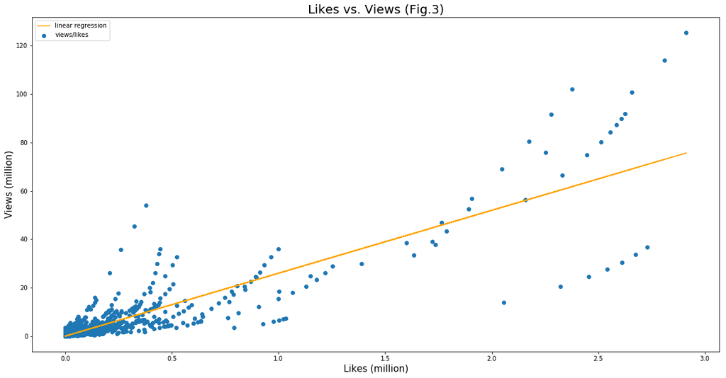

```python
fig,ax = plt.subplots()
ax.scatter(data.likes/1000000,data.views/1000000,label='views/likes')
ax.set_xlabel('Likes (million)',fontsize=15)
ax.set_ylabel('Views (million)',fontsize=15)
ax.set_title('Likes vs. Views (Fig.3)',fontsize=20)
fig.set_size_inches(20, 10)

reg = np.poly1d(np.polyfit(x=data.likes/1000000,y=data.views/1000000,deg=1))
ax.plot(data.likes/1000000,reg(data.likes/1000000),'orange',label='linear regression')

ax.legend()
```

### 4.1.2 Curve fit

Different from linear regression, a curve fit is nonlinear and requires a initial guess on the function.

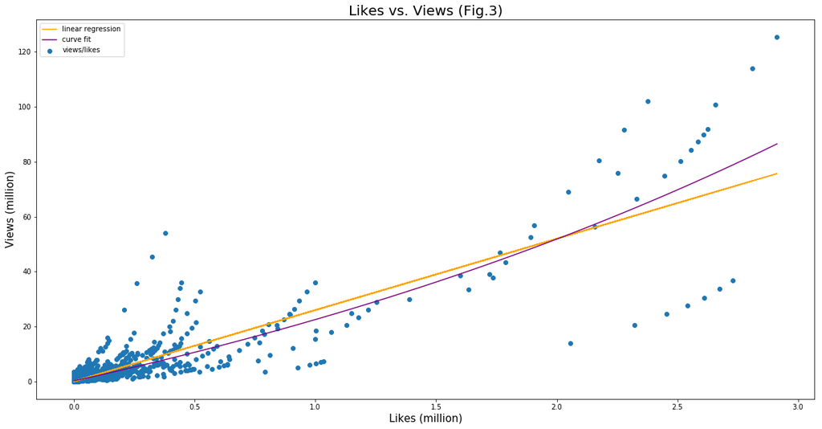

```python
from matplotlib.pyplot import cm
from scipy.optimize import curve_fit

fig,ax = plt.subplots()
ax.scatter(data.likes/1000000,data.views/1000000,label='views/likes')
ax.set_xlabel('Likes (million)',fontsize=15)
ax.set_ylabel('Views (million)',fontsize=15)
ax.set_title('Likes vs. Views (Fig.3)',fontsize=20)
fig.set_size_inches(20, 10)

reg = np.poly1d(np.polyfit(x=data.likes/1000000,y=data.views/1000000,deg=1))
ax.plot(data.likes/1000000,reg(data.likes/1000000),'orange',label='linear regression')

def func(x, a, b, c):
    return a + b* np.exp(c * x)

guess = [50, 50,-.01]
guessedFactors = [func(x,*guess) for x in data.likes/1000000]

popt,pcov = curve_fit(func, data.likes/1000000, data.views/1000000,guess)

xpos = np.linspace(min(data.likes/1000000),max(data.likes/1000000),50)
ypos = [func(x,*popt) for x in xpos]

ax.plot(xpos,ypos,color='purple',label="curve fit")

ax.legend()
```

In the example above, I chose exponential model as the initial guess of the regression because the scatter plot visually looks like that it has an exponential pattern. However, in practices, judging by the different shapes of the data dots, you should give a second thought to other possible regression model.